# DATS 6101 Project 1

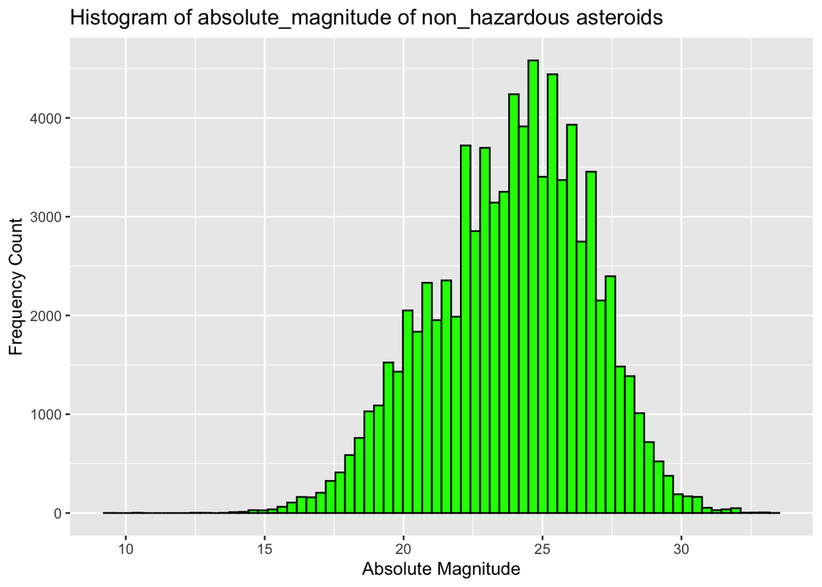

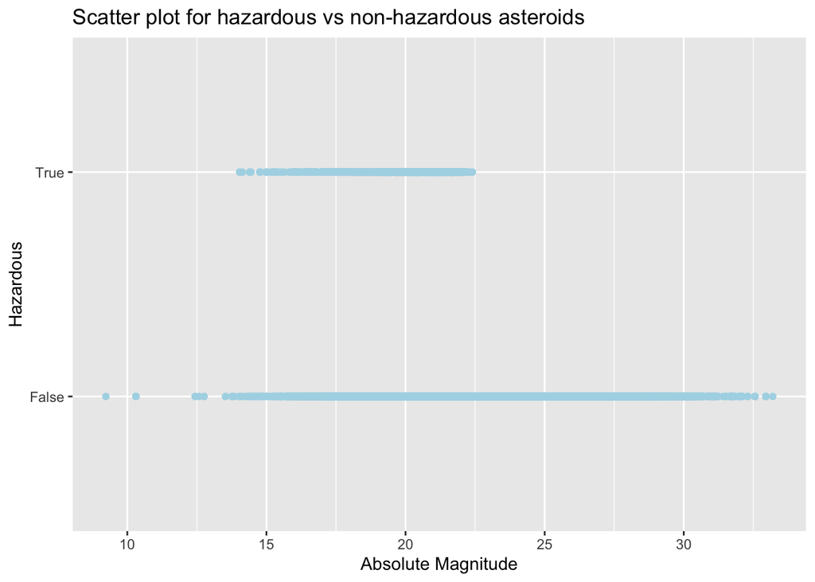

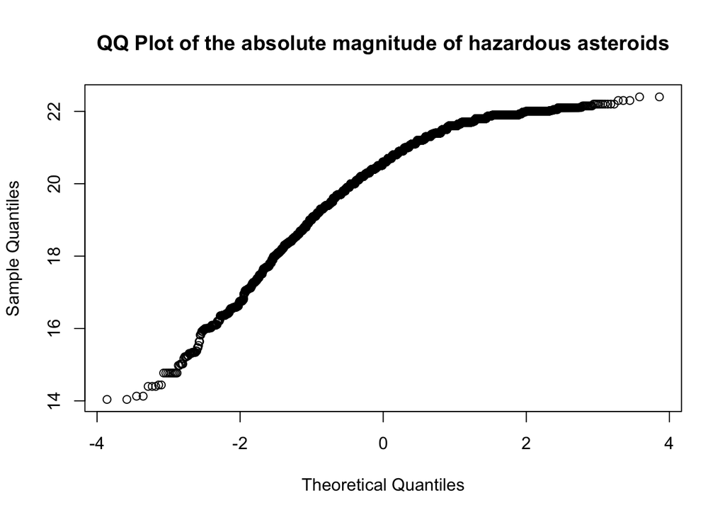

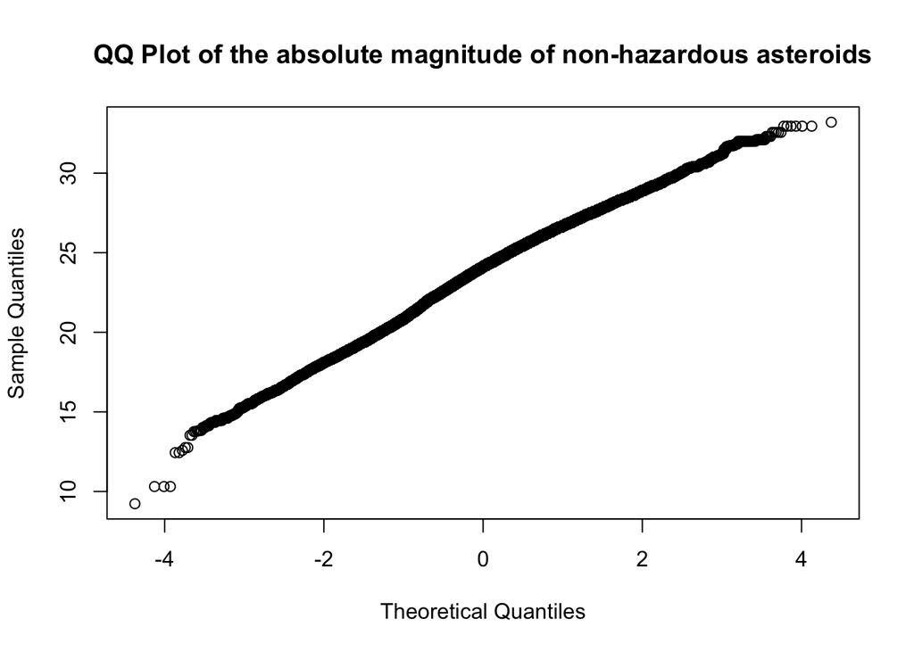

Note - We see that the absolute_magnitude for hazardous NEO lies mostly between 19 to 22. While that of the non-hazardous asteroids gnerally lies between 23 to 27.

## Outliers

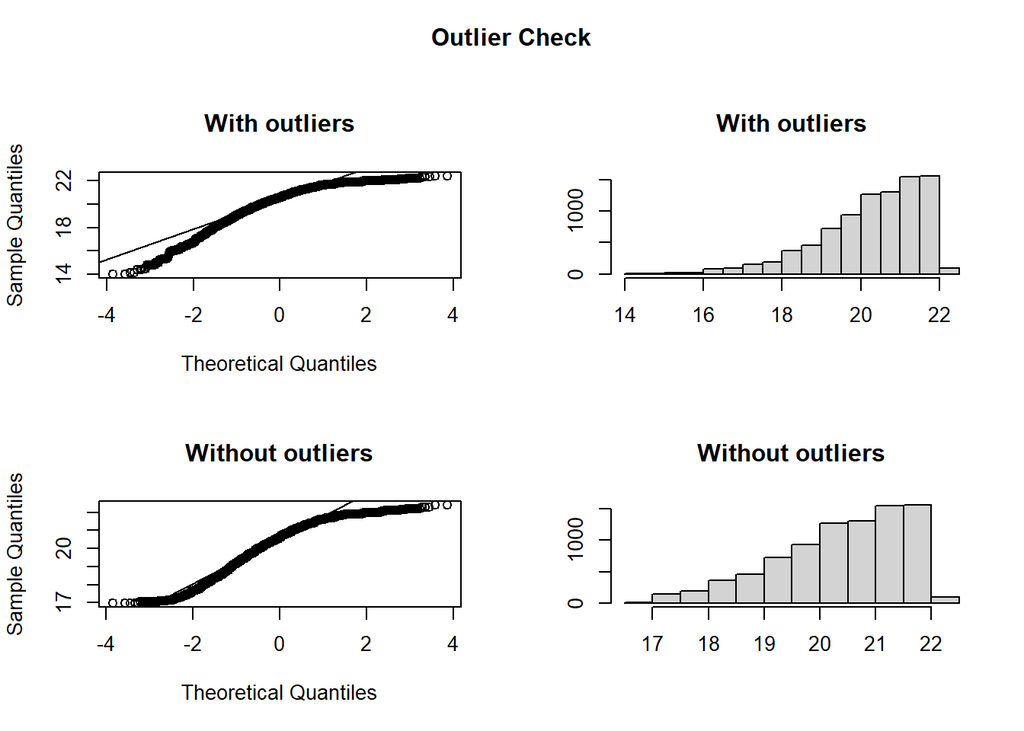

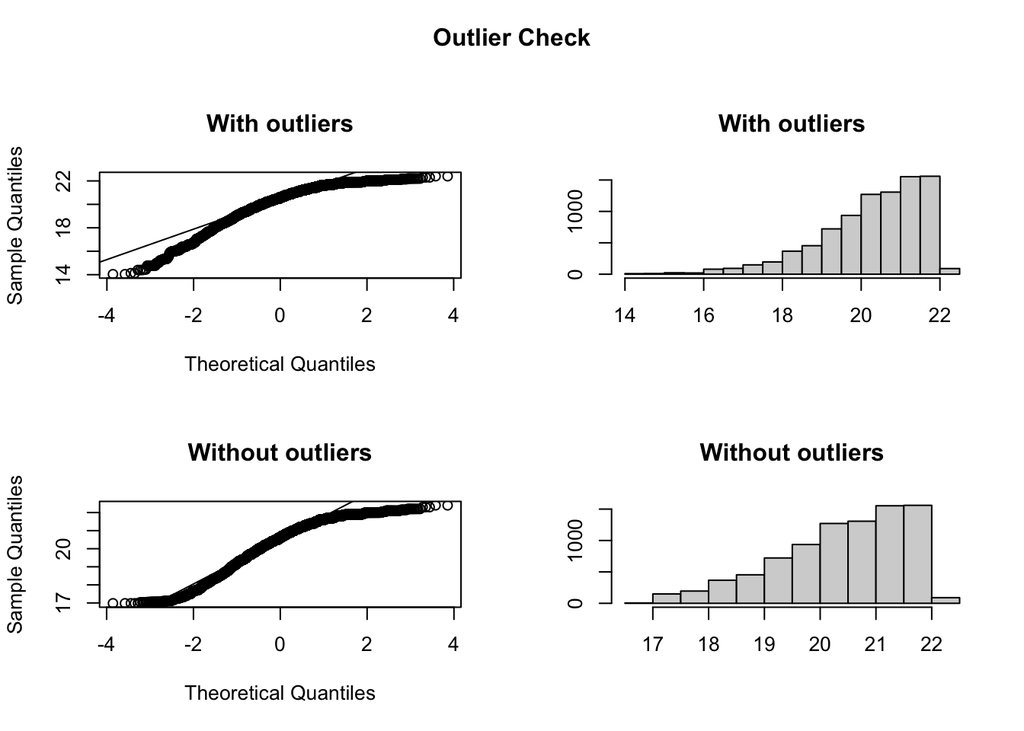

```
## Outliers identified: 231
## Proportion (%) of outliers: 2.7
## Mean of the outliers: 16.1
## Mean without removing outliers: 20.3
## Mean if we remove outliers: 20.4
## Outliers successfully removed
```

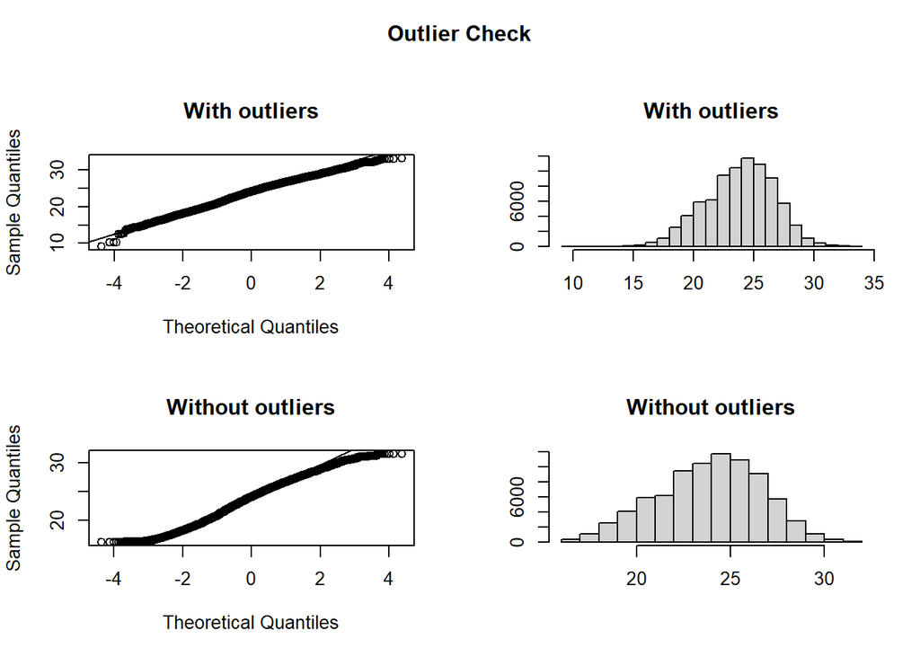

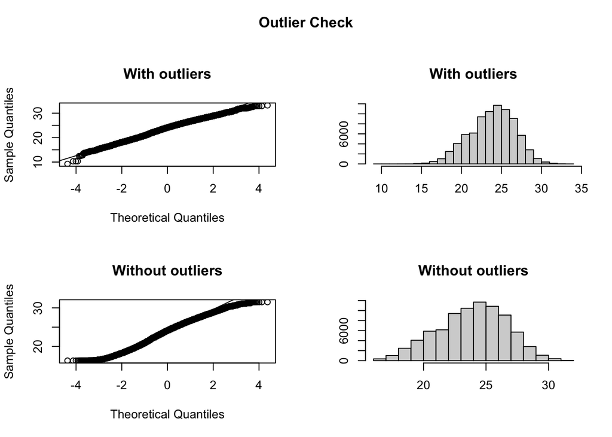

```
## Outliers identified: 446
## Proportion (%) of outliers: 0.5
## Mean of the outliers: 18.9
## Mean without removing outliers: 23.9
## Mean if we remove outliers: 23.9
## Outliers successfully removed
```

## T-Tests

Now, with all outliers removed and distinct values extracted, we can perform t-tests.

T-Tests on hazardous dataframe:

```
##
##  One Sample t-test
##
## data:  hazardous_grouped$absolute_magnitude
## t = 670, df = 2172, p-value <2e-16
## alternative hypothesis: true mean is not equal to 0
## 95 percent confidence interval:
##  20.1 20.3
## sample estimates:
## mean of x
##      20.2
```

T-Tests on non_hazardous dataframe:

```
##
##  One Sample t-test
##
## data:  non_hazardous_grouped$absolute_magnitude
## t = 1341, df = 25249, p-value <2e-16
## alternative hypothesis: true mean is not equal to 0
## 95 percent confidence interval:
##  23.6 23.7
## sample estimates:
## mean of x
##      23.6
```

## Contingency Table

Now, we shall validate the above by printing the Contingency table. The contingency table of hazardous is below:

```
##
## (16,16.5] (16.5,17] (17,17.5] (17.5,18] (18,18.5] (18.5,19] (19,19.5] (19.5,20]
##        21        23        39        58       107       134       191       240
## (20,20.5] (20.5,21] (21,21.5] (21.5,22] (22,22.5] (22.5,23]
##       296       302       352       368        17         0
```

We see a higher frequency of values falling in the interval 21-22 for hazardous asteroids. However, as noticed in the plots drawn, the plot is left skewed. Hence, the average/mean shifted a bit towards the left.

The contingency table of non_hazardous is below:

```
##
## (16,16.5] (16.5,17] (17,17.5] (17.5,18] (18,18.5] (18.5,19] (19,19.5] (19.5,20]
##        76        92       161       233       401       527       706       795
## (20,20.5] (20.5,21] (21,21.5] (21.5,22] (22,22.5] (22.5,23] (23,23.5] (23.5,24]
##       913      1015       933       933      1349      1397      1600      1744
## (24,24.5] (24.5,25] (25,25.5] (25.5,26] (26,26.5] (26.5,27] (27,27.5] (27.5,28]
##      1905      1908      1830      1556      1430      1162       854       625
## (28,28.5] (28.5,29] (29,29.5] (29.5,30] (30,30.5] (30.5,31] (31,31.5] (31.5,32]
##       404       247       160        98        50        22        11        10
```

We see a higher frequency of values falling in the interval 24-25 for non_hazardous.

## Anova Test:

For anova test, we need 2 samples of equal size - one from hazardous and another from non-hazardous

[output not shown]

## Correlation with Diameter

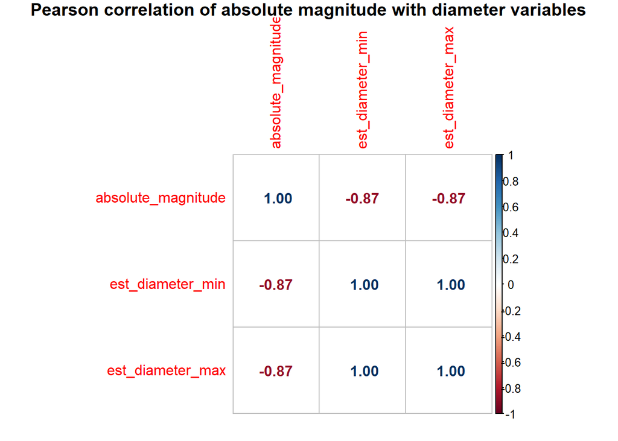

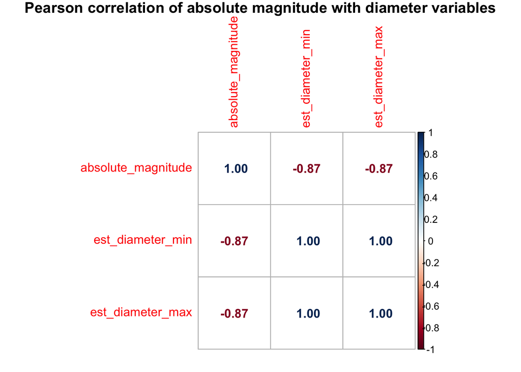

As noted in the above correlation plot, we see that the the min and max estimated diameter is closely related to the absolute magnitude. It is inversely related. This makes sense because absolute magnitude (brightness of a NEO) indicates the size of the asteroid in question. And hence, we can say that the bigger the size of the asteroid, lesser the absolute magnitude (brighter the star), and thus potentially more hazardous is the asteroid.

# Overall Correlation Plots:

After exploring each of these 3 variables, we shall now see their correlation with that of our target variable - hazardous. We shall draw both - Pearson and Spearman correlation plots.

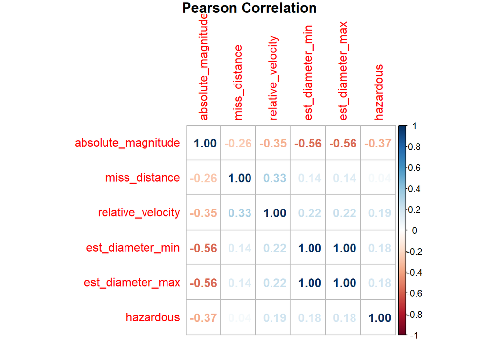

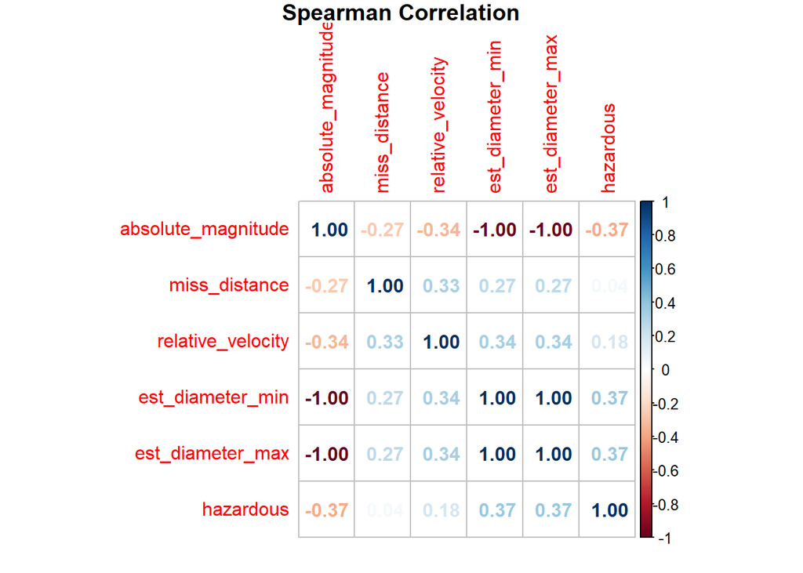

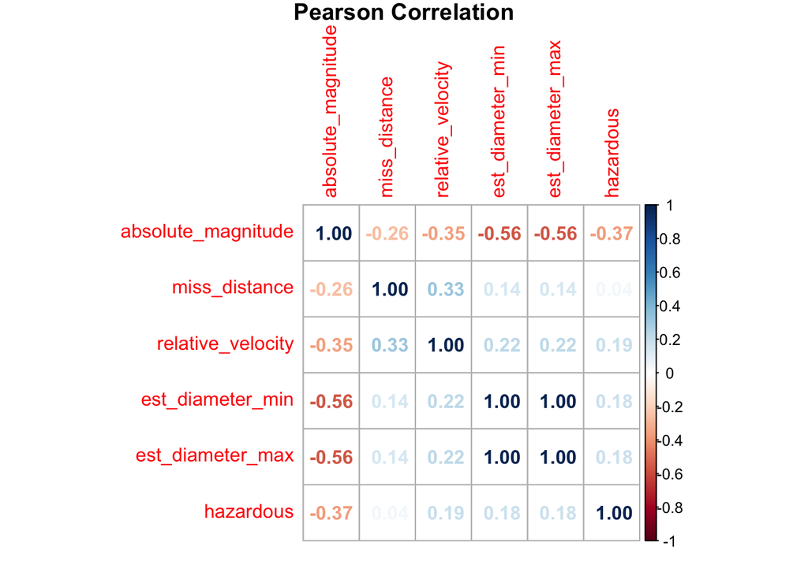

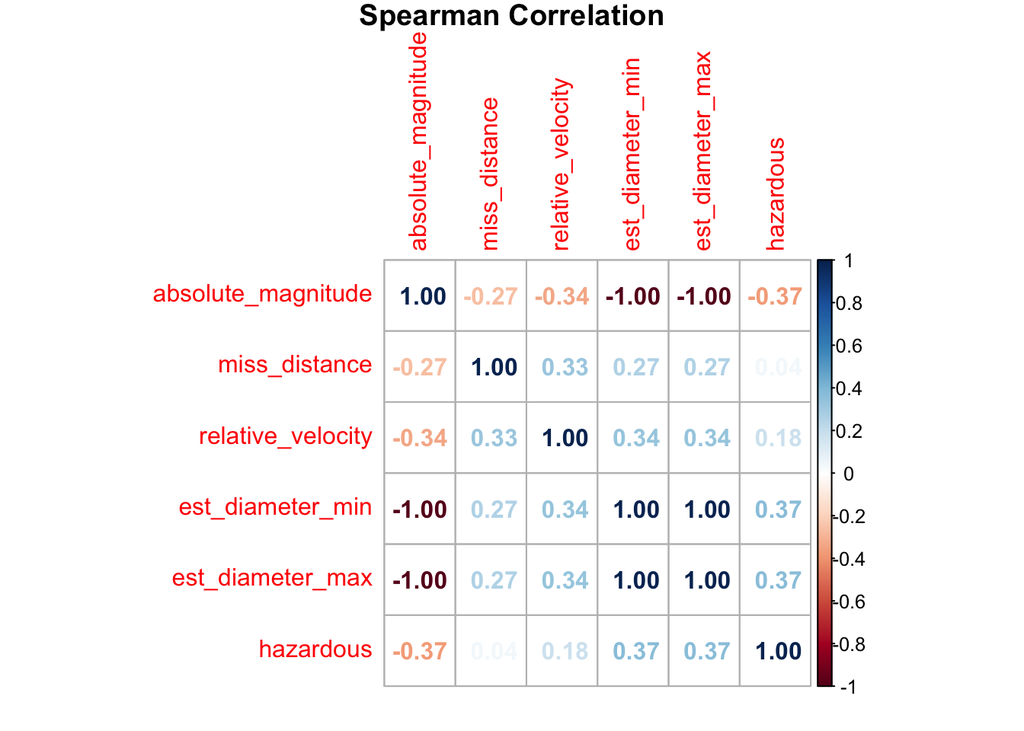

# Limitations

The `neo.csv` data set posed limitations in the variables, description and dictionary. Since the dataset was obtained from a web-based environment, kaggle, we had insufficient variables, a poor description of the dataset and no data dictionary provided. In terms of the variables provided, it would have been ideal to have one regarding the trajectory towards, or away, from earth, as well as other potentially hazardous, or not hazardous, variables. Nevertheless, we were restricted to just using the three variables that were quantifiable in order to characterize the potential of it being hazardous. In retrospect, just using these three variables might have been an over-simplification in our determination of a hazard. On the other hand, the description of the dataset is very limited given the constraint of using Kaggle. It would have been better if the dataset was obtained straight from a NASA website or API, however this was not possible. It would have been a huge perk to know how these variables are being used by NASA professionals, what characterizes an instance to be recorded multiple times, and why they initially attributed the boolean value for Hazardous. Finally, when it came to providing a data dictionary, the kaggle website did not have one. Thus, we had to do our own research as to what these variables meant, and what they were describing. Therefore, with insufficient variables, a poor description and no data dictionary it was difficult to infer, or fully understand, the root of a hazardous or not hazardous asteroid to fully answer our question.

# Github

The screenshot below shows the [github](https://github.com/Rapid-Red-Mustang/DS-Project-1) contributions made by us individually:

[figure not shown]

# References:

- Kaggle Dataset (Kaggle): Vani, S. (2022, June 17). NASA - Nearest Earth objects. Kaggle. Retrieved November 2, 2022, from https://www.kaggle.com/datasets/sameepvani/nasa-nearest-earth-objects
- Center for Near Earth Objects Studies (CNEOS): NASA. (n.d.). Neo basics. NASA. Retrieved November 2, 2022, from https://cneos.jpl.nasa.gov/about/neo_groups.html
- NASA (NASA): Bardan, R. (2022, October 11). NASA confirms Dart Mission Impact Changed Asteroid’s motion in space. NASA. Retrieved November 2, 2022, from https://www.nasa.gov/press-release/nasa-confirms-dart-mission-impact-changed-asteroid-s-motion-in-space

Araujo, R. A. N., & Winter, O. C. (2014). Near-Earth asteroid binaries in close encounters with the Earth. Astronomy & Astrophysics, 566, A23.

Peter O. K. Krehl (2008). History of Shock Waves, Explosions and Impact: A Chronological and Biographical Reference. Springer Science & Business Media. p. 404. ISBN 978-3-540-30421-0.

Tonry, J. L. (2010). An early warning system for asteroid impact. Publications of the Astronomical Society of the Pacific, 123(899), 58.